# Data analysis with R and the tidyverse

# 1 Intro and Overview

## 1.1 Pre-requisites

### 1.1.1 R and RStudio

Make sure that **R** and **RStudio** are installed in your computer. You can create a new **R Script** in **RStudio** to copy example source code from this tutorial and write code for the exercises. Save the script in your home directory (or a sub directory of your choice). To run the code written on the current line (or of selected lines), click on button **Run** or press **CTRL+ENTER**. Results will be displayed either in the **RStudio**’s console or the Viewer panel (graphics). To read the documentation about a function (Help panel), in the script, place the cursor on the function’s name and press F1.

### 1.1.2 The tidyverse

This tutorial is based on a powerful set of packages for data manipulation and visualization known as the **tidyverse**. We will also need the **readxl** package to enable reading data from Microsoft Excel files. So, make sure that those 2 packages (tidyverse and readxl) have been installed in your R environment (see RStudio’s menu Tools/Install Packages…).

## 1.2 Introduction

Because of the ever-growing number of publicly available and large datasets in life sciences, computational and statistical skills are becoming a key part of the life scientist’s curriculum.

The goal of this tutorial is to give you a foundation in the most important tools for data analysis in R. You can then complement and expand your knowledge on your own in order to perform more complex analyses.

This tutorial is an adaptation of Dr. Alanis-Lobato’s tutorial that borrows materials and concepts from the book [R for Data Science](https://r4ds.had.co.nz/) by Garret Grolemund and Hadley Wickham.

## 1.3 Overview

In most data analysis projects you will have to do as shown below. The **tidyverse** set of packages include functions to tackle each one of the parts of the data analysis process.

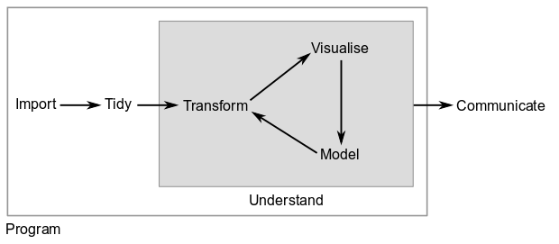

### 1.3.1 Import

The first step in data science is to **import** your data into R in order to manipulate it with R functions. This means that you will take data stored in a file, database or website and load it into a variable in R. These datasets can be the output of a genomics project, the result of a survey, measurements done in the lab, etc. In this tutorial, you will use functions from the **readr** and **readxl** packages to load data tables into R.

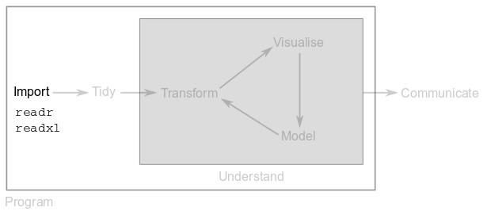

### 1.3.2 Tidy

Second, you will have to **tidy** up your data. Briefly, in a tidy dataset each row is an observation or a sample and each column is a variable. If your data is tidy and has a consistent structure, you will be able to use it seamlessly throughout the **tidyverse** functions for analysis, manipulation and visualization. In this tutorial, you will use functions from the **tidyr** package to tidy up your data.

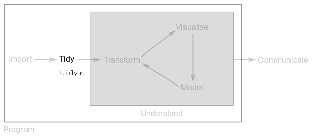

### 1.3.3 Transform

Once your data is tidy, often times you need to **transform** it. Common transformations include normalization, the creation of new variables from existing ones (e.g. convert from inches to centimeters) or the computation of summary statistics (e.g. means and counts). In this tutorial, you will use functions from the **dplyr** package (the **d** comes from data-frame and **plyr** from “pliers”, the pincers for gripping small objects or bending wire) to perform data transformations.

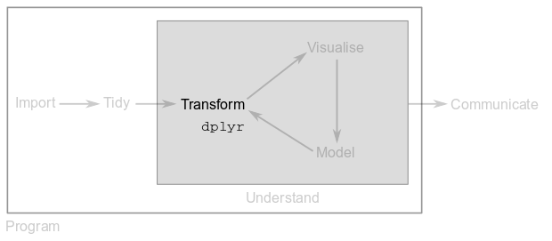

### 1.3.4 visualize and model

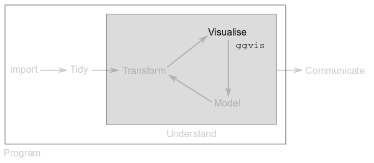

**Models** are complementary to visualizations. Models are mathematical representations of a system that are often derived from precise data analyzes and observations. Models are key to making predictions that can be later tested in the lab.

Even though there are powerful tools in R for data modeling, in this tutorial you will only propose simple models based on visualizations.

It is important to stress that visualization and modeling will often derive in new questions and hypotheses that will bring you back to the data transformation step. With new variables and stats, you can visualize again and fine tune your model.

### 1.3.5 Program

Surrounding all the above steps is **programming**, a critical part of any data analysis project. You do not need to be an expert programmer to analyze data, but programming skills allow you to automate common tasks and solve new problems more easily. There are hundreds of programming languages out there, but **R** and its rich collection of packages, functions and data are particularly useful when it comes to doing statistics and data analysis.

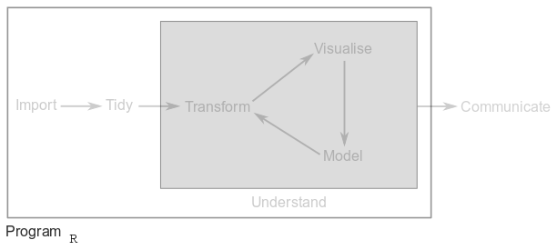

### 1.3.6 Communicate

Cool graphics and precise models are of no use if you cannot **communicate** your results to others. Communication of methods and results can be done via oral or poster presentations, theses, scientific articles, reports, etc. There are tons of tools for communication of data analyzes, from PowerPoint or Word to web pages and **R Markdown**. These interactive notes have been written with the latter.

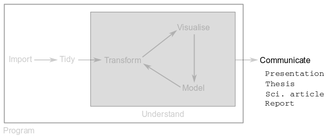